# BIS 15L Midterm 2

Kaylah Marcello

## Instructions

Answer the following questions and complete the exercises in RMarkdown. Please embed all of your code and push your final work to your repository. Your code should be organized, clean, and run free from errors. Be sure to **add your name** to the author header above. You may use any resources to answer these questions (including each other), but you may not post questions to Open Stacks or external help sites. There are 10 total questions.

Make sure to use the formatting conventions of RMarkdown to make your report neat and clean! Your plots should use consistent aesthetics throughout.

This exam is due by **12:00p on Tuesday, February 22**.

## Gapminder

For this assignment, we are going to use data from [gapminder](https://www.gapminder.org/). Gapminder includes information about economics, population, social issues, and life expectancy from countries all over the world. We will use three data sets, so please load all three as separate objects.

```r
library(tidyverse)
library(janitor)
library(skimr)
library(RColorBrewer)
library(paletteer)
library(here)
library("remotes")
library(ggthemes)
```

1. population_total.csv

```r
population_total <- readr::read_csv("data/population_total.csv")
```

2. income_per_person_gdppercapita_ppp_inflation_adjusted.csv

```r
income_per_person <- readr::read_csv("data/income_per_person_gdppercapita_ppp_inflation_adjusted.csv")
```

3. life_expectancy_years.csv

```r
life_expectancy <- readr::read_csv("data/life_expectancy_years.csv")
```

1. (3 points) Once you have an idea of the structure of the data, please make each data set tidy (hint: think back to pivots) and store them as new objects. You will need both the original (wide) and tidy (long) data! note: ALL DATA NEEDS TO BE PIVOTED LONGER

## population_total

```r
names(population_total)
```

```
##   [1] "country" "1800"    "1801"    "1802"    "1803"    "1804"    "1805"
##   [8] "1806"    "1807"    "1808"    "1809"    "1810"    "1811"    "1812"
##  [15] "1813"    "1814"    "1815"    "1816"    "1817"    "1818"    "1819"
##  [22] "1820"    "1821"    "1822"    "1823"    "1824"    "1825"    "1826"
##  [29] "1827"    "1828"    "1829"    "1830"    "1831"    "1832"    "1833"
##  [36] "1834"    "1835"    "1836"    "1837"    "1838"    "1839"    "1840"
##  [43] "1841"    "1842"    "1843"    "1844"    "1845"    "1846"    "1847"
##  [50] "1848"    "1849"    "1850"    "1851"    "1852"    "1853"    "1854"
##  [57] "1855"    "1856"    "1857"    "1858"    "1859"    "1860"    "1861"
##  [64] "1862"    "1863"    "1864"    "1865"    "1866"    "1867"    "1868"
##  [71] "1869"    "1870"    "1871"    "1872"    "1873"    "1874"    "1875"
##  [78] "1876"    "1877"    "1878"    "1879"    "1880"    "1881"    "1882"
##  [85] "1883"    "1884"    "1885"    "1886"    "1887"    "1888"    "1889"
##  [92] "1890"    "1891"    "1892"    "1893"    "1894"    "1895"    "1896"
##  [99] "1897"    "1898"    "1899"    "1900"    "1901"    "1902"    "1903"
```

[output cut: 29 more lines]

```r
glimpse(population_total)
```

```
## Rows: 195
## Columns: 302
## $ country <chr> "Afghanistan", "Albania", "Algeria", "Andorra", "Angola", "Ant…
## $ `1800`  <dbl> 3280000, 400000, 2500000, 2650, 1570000, 37000, 534000, 413000…
## $ `1801`  <dbl> 3280000, 402000, 2510000, 2650, 1570000, 37000, 520000, 413000…
## $ `1802`  <dbl> 3280000, 404000, 2520000, 2650, 1570000, 37000, 506000, 413000…
## $ `1803`  <dbl> 3280000, 405000, 2530000, 2650, 1570000, 37000, 492000, 413000…
## $ `1804`  <dbl> 3280000, 407000, 2540000, 2650, 1570000, 37000, 479000, 413000…
## $ `1805`  <dbl> 3280000, 409000, 2550000, 2650, 1570000, 37000, 466000, 413000…
## $ `1806`  <dbl> 3280000, 411000, 2560000, 2650, 1570000, 37000, 453000, 413000…
## $ `1807`  <dbl> 3280000, 413000, 2560000, 2650, 1570000, 37000, 441000, 413000…
## $ `1808`  <dbl> 3280000, 414000, 2570000, 2650, 1570000, 37000, 429000, 413000…
## $ `1809`  <dbl> 3280000, 416000, 2580000, 2650, 1570000, 37000, 417000, 413000…
## $ `1810`  <dbl> 3280000, 418000, 2590000, 2650, 1570000, 37000, 420000, 413000…
## $ `1811`  <dbl> 3280000, 420000, 2600000, 2650, 1570000, 37000, 422000, 413000…
```

[output cut: 289 more lines]

```r
head(population_total)
```

```
## # A tibble: 6 × 302
##   country  `1800` `1801` `1802` `1803` `1804` `1805` `1806` `1807` `1808` `1809`
##   <chr>     <dbl>  <dbl>  <dbl>  <dbl>  <dbl>  <dbl>  <dbl>  <dbl>  <dbl>  <dbl>
## 1 Afghani… 3.28e6 3.28e6 3.28e6 3.28e6 3.28e6 3.28e6 3.28e6 3.28e6 3.28e6 3.28e6
## 2 Albania  4   e5 4.02e5 4.04e5 4.05e5 4.07e5 4.09e5 4.11e5 4.13e5 4.14e5 4.16e5
## 3 Algeria  2.5 e6 2.51e6 2.52e6 2.53e6 2.54e6 2.55e6 2.56e6 2.56e6 2.57e6 2.58e6
## 4 Andorra  2.65e3 2.65e3 2.65e3 2.65e3 2.65e3 2.65e3 2.65e3 2.65e3 2.65e3 2.65e3
## 5 Angola   1.57e6 1.57e6 1.57e6 1.57e6 1.57e6 1.57e6 1.57e6 1.57e6 1.57e6 1.57e6
## 6 Antigua… 3.7 e4 3.7 e4 3.7 e4 3.7 e4 3.7 e4 3.7 e4 3.7 e4 3.7 e4 3.7 e4 3.7 e4
## # … with 291 more variables: 1810 <dbl>, 1811 <dbl>, 1812 <dbl>, 1813 <dbl>,
## #   1814 <dbl>, 1815 <dbl>, 1816 <dbl>, 1817 <dbl>, 1818 <dbl>, 1819 <dbl>,
## #   1820 <dbl>, 1821 <dbl>, 1822 <dbl>, 1823 <dbl>, 1824 <dbl>, 1825 <dbl>,
## #   1826 <dbl>, 1827 <dbl>, 1828 <dbl>, 1829 <dbl>, 1830 <dbl>, 1831 <dbl>,
## #   1832 <dbl>, 1833 <dbl>, 1834 <dbl>, 1835 <dbl>, 1836 <dbl>, 1837 <dbl>,
## #   1838 <dbl>, 1839 <dbl>, 1840 <dbl>, 1841 <dbl>, 1842 <dbl>, 1843 <dbl>,
## #   1844 <dbl>, 1845 <dbl>, 1846 <dbl>, 1847 <dbl>, 1848 <dbl>, 1849 <dbl>, …
```

```r
population_longer <- population_total %>%
  pivot_longer(-country,
               names_to = "year",
               values_to = "population")
population_longer
```

```
## # A tibble: 58,695 × 3
##    country     year  population
##    <chr>       <chr>      <dbl>
##  1 Afghanistan 1800     3280000
##  2 Afghanistan 1801     3280000
##  3 Afghanistan 1802     3280000
##  4 Afghanistan 1803     3280000
##  5 Afghanistan 1804     3280000
##  6 Afghanistan 1805     3280000
##  7 Afghanistan 1806     3280000
##  8 Afghanistan 1807     3280000
##  9 Afghanistan 1808     3280000
## 10 Afghanistan 1809     3280000
## # … with 58,685 more rows
```

## income_per_person

```r
names(income_per_person)
```

```
##   [1] "country" "1800"    "1801"    "1802"    "1803"    "1804"    "1805"
##   [8] "1806"    "1807"    "1808"    "1809"    "1810"    "1811"    "1812"
##  [15] "1813"    "1814"    "1815"    "1816"    "1817"    "1818"    "1819"
##  [22] "1820"    "1821"    "1822"    "1823"    "1824"    "1825"    "1826"
##  [29] "1827"    "1828"    "1829"    "1830"    "1831"    "1832"    "1833"
##  [36] "1834"    "1835"    "1836"    "1837"    "1838"    "1839"    "1840"
##  [43] "1841"    "1842"    "1843"    "1844"    "1845"    "1846"    "1847"
##  [50] "1848"    "1849"    "1850"    "1851"    "1852"    "1853"    "1854"
##  [57] "1855"    "1856"    "1857"    "1858"    "1859"    "1860"    "1861"
##  [64] "1862"    "1863"    "1864"    "1865"    "1866"    "1867"    "1868"
##  [71] "1869"    "1870"    "1871"    "1872"    "1873"    "1874"    "1875"
##  [78] "1876"    "1877"    "1878"    "1879"    "1880"    "1881"    "1882"
##  [85] "1883"    "1884"    "1885"    "1886"    "1887"    "1888"    "1889"
##  [92] "1890"    "1891"    "1892"    "1893"    "1894"    "1895"    "1896"
##  [99] "1897"    "1898"    "1899"    "1900"    "1901"    "1902"    "1903"
```

[output cut: 20 more lines]

```r
glimpse(income_per_person)
```

```
## Rows: 193
## Columns: 242
## $ country <chr> "Afghanistan", "Albania", "Algeria", "Andorra", "Angola", "Ant…
## $ `1800`  <dbl> 603, 667, 715, 1200, 618, 757, 1640, 514, 817, 1850, 775, 1450…
## $ `1801`  <dbl> 603, 667, 716, 1200, 620, 757, 1640, 514, 822, 1850, 775, 1450…
## $ `1802`  <dbl> 603, 667, 717, 1200, 623, 757, 1650, 514, 826, 1860, 775, 1450…
## $ `1803`  <dbl> 603, 667, 718, 1200, 626, 757, 1650, 514, 831, 1870, 775, 1450…
## $ `1804`  <dbl> 603, 667, 719, 1210, 628, 757, 1660, 514, 836, 1880, 775, 1450…
## $ `1805`  <dbl> 603, 668, 720, 1210, 631, 757, 1660, 514, 841, 1880, 776, 1450…
## $ `1806`  <dbl> 603, 668, 721, 1210, 634, 757, 1670, 514, 845, 1890, 776, 1450…
## $ `1807`  <dbl> 603, 668, 722, 1210, 637, 758, 1680, 514, 850, 1900, 776, 1450…
## $ `1808`  <dbl> 603, 668, 723, 1220, 640, 758, 1680, 514, 855, 1910, 776, 1450…
## $ `1809`  <dbl> 603, 668, 724, 1220, 642, 758, 1690, 514, 860, 1920, 776, 1450…
## $ `1810`  <dbl> 604, 668, 725, 1220, 645, 758, 1690, 514, 865, 1920, 777, 1450…
## $ `1811`  <dbl> 604, 668, 726, 1220, 648, 758, 1700, 515, 869, 1940, 777, 1450…
```

[output cut: 229 more lines]

```r
head(income_per_person)
```

```
## # A tibble: 6 × 242
##   country  `1800` `1801` `1802` `1803` `1804` `1805` `1806` `1807` `1808` `1809`
##   <chr>     <dbl>  <dbl>  <dbl>  <dbl>  <dbl>  <dbl>  <dbl>  <dbl>  <dbl>  <dbl>
## 1 Afghani…    603    603    603    603    603    603    603    603    603    603
## 2 Albania     667    667    667    667    667    668    668    668    668    668
## 3 Algeria     715    716    717    718    719    720    721    722    723    724
## 4 Andorra    1200   1200   1200   1200   1210   1210   1210   1210   1220   1220
## 5 Angola      618    620    623    626    628    631    634    637    640    642
## 6 Antigua…    757    757    757    757    757    757    757    758    758    758
## # … with 231 more variables: 1810 <dbl>, 1811 <dbl>, 1812 <dbl>, 1813 <dbl>,
## #   1814 <dbl>, 1815 <dbl>, 1816 <dbl>, 1817 <dbl>, 1818 <dbl>, 1819 <dbl>,
## #   1820 <dbl>, 1821 <dbl>, 1822 <dbl>, 1823 <dbl>, 1824 <dbl>, 1825 <dbl>,
## #   1826 <dbl>, 1827 <dbl>, 1828 <dbl>, 1829 <dbl>, 1830 <dbl>, 1831 <dbl>,
## #   1832 <dbl>, 1833 <dbl>, 1834 <dbl>, 1835 <dbl>, 1836 <dbl>, 1837 <dbl>,
## #   1838 <dbl>, 1839 <dbl>, 1840 <dbl>, 1841 <dbl>, 1842 <dbl>, 1843 <dbl>,
## #   1844 <dbl>, 1845 <dbl>, 1846 <dbl>, 1847 <dbl>, 1848 <dbl>, 1849 <dbl>, …
```

```r
income_longer <- income_per_person %>%
  pivot_longer(-country,
               names_to = "year",
               values_to = "income")
income_longer
```

```
## # A tibble: 46,513 × 3
##    country     year  income
##    <chr>       <chr>  <dbl>
##  1 Afghanistan 1800     603
##  2 Afghanistan 1801     603
##  3 Afghanistan 1802     603
##  4 Afghanistan 1803     603
##  5 Afghanistan 1804     603
##  6 Afghanistan 1805     603
##  7 Afghanistan 1806     603
##  8 Afghanistan 1807     603
##  9 Afghanistan 1808     603
## 10 Afghanistan 1809     603
## # … with 46,503 more rows
```

## life_expectancy

```r
names(life_expectancy)
```

```
##   [1] "country" "1800"    "1801"    "1802"    "1803"    "1804"    "1805"
##   [8] "1806"    "1807"    "1808"    "1809"    "1810"    "1811"    "1812"
##  [15] "1813"    "1814"    "1815"    "1816"    "1817"    "1818"    "1819"
##  [22] "1820"    "1821"    "1822"    "1823"    "1824"    "1825"    "1826"
##  [29] "1827"    "1828"    "1829"    "1830"    "1831"    "1832"    "1833"
##  [36] "1834"    "1835"    "1836"    "1837"    "1838"    "1839"    "1840"
##  [43] "1841"    "1842"    "1843"    "1844"    "1845"    "1846"    "1847"
##  [50] "1848"    "1849"    "1850"    "1851"    "1852"    "1853"    "1854"
##  [57] "1855"    "1856"    "1857"    "1858"    "1859"    "1860"    "1861"
##  [64] "1862"    "1863"    "1864"    "1865"    "1866"    "1867"    "1868"
##  [71] "1869"    "1870"    "1871"    "1872"    "1873"    "1874"    "1875"
##  [78] "1876"    "1877"    "1878"    "1879"    "1880"    "1881"    "1882"
##  [85] "1883"    "1884"    "1885"    "1886"    "1887"    "1888"    "1889"
##  [92] "1890"    "1891"    "1892"    "1893"    "1894"    "1895"    "1896"
##  [99] "1897"    "1898"    "1899"    "1900"    "1901"    "1902"    "1903"
```

[output cut: 29 more lines]

```r
glimpse(life_expectancy)
```

```
## Rows: 187
## Columns: 302
## $ country <chr> "Afghanistan", "Albania", "Algeria", "Andorra", "Angola", "Ant…
## $ `1800`  <dbl> 28.2, 35.4, 28.8, NA, 27.0, 33.5, 33.2, 34.0, 34.0, 34.4, 29.2…
## $ `1801`  <dbl> 28.2, 35.4, 28.8, NA, 27.0, 33.5, 33.2, 34.0, 34.0, 34.4, 29.2…
## $ `1802`  <dbl> 28.2, 35.4, 28.8, NA, 27.0, 33.5, 33.2, 34.0, 34.0, 34.4, 29.2…
## $ `1803`  <dbl> 28.2, 35.4, 28.8, NA, 27.0, 33.5, 33.2, 34.0, 34.0, 34.4, 29.2…
## $ `1804`  <dbl> 28.2, 35.4, 28.8, NA, 27.0, 33.5, 33.2, 34.0, 34.0, 34.4, 29.2…
## $ `1805`  <dbl> 28.2, 35.4, 28.8, NA, 27.0, 33.5, 33.2, 34.0, 34.0, 34.4, 29.2…
## $ `1806`  <dbl> 28.1, 35.4, 28.8, NA, 27.0, 33.5, 33.2, 34.0, 34.0, 34.4, 29.2…
## $ `1807`  <dbl> 28.1, 35.4, 28.8, NA, 27.0, 33.5, 33.2, 34.0, 34.0, 34.4, 29.2…
## $ `1808`  <dbl> 28.1, 35.4, 28.8, NA, 27.0, 33.5, 33.2, 34.0, 34.0, 34.4, 29.2…
## $ `1809`  <dbl> 28.1, 35.4, 28.8, NA, 27.0, 33.5, 33.2, 34.0, 34.0, 34.4, 29.2…
## $ `1810`  <dbl> 28.1, 35.4, 28.8, NA, 27.0, 33.5, 33.2, 34.0, 34.0, 34.4, 29.2…
## $ `1811`  <dbl> 28.1, 35.4, 28.8, NA, 27.0, 33.5, 33.2, 34.0, 34.0, 34.4, 29.2…
```

[output cut: 289 more lines]

```r
head(life_expectancy)
```

```
## # A tibble: 6 × 302
##   country  `1800` `1801` `1802` `1803` `1804` `1805` `1806` `1807` `1808` `1809`
##   <chr>     <dbl>  <dbl>  <dbl>  <dbl>  <dbl>  <dbl>  <dbl>  <dbl>  <dbl>  <dbl>
## 1 Afghani…   28.2   28.2   28.2   28.2   28.2   28.2   28.1   28.1   28.1   28.1
## 2 Albania    35.4   35.4   35.4   35.4   35.4   35.4   35.4   35.4   35.4   35.4
## 3 Algeria    28.8   28.8   28.8   28.8   28.8   28.8   28.8   28.8   28.8   28.8
## 4 Andorra    NA     NA     NA     NA     NA     NA     NA     NA     NA     NA
## 5 Angola     27     27     27     27     27     27     27     27     27     27
## 6 Antigua…   33.5   33.5   33.5   33.5   33.5   33.5   33.5   33.5   33.5   33.5
## # … with 291 more variables: 1810 <dbl>, 1811 <dbl>, 1812 <dbl>, 1813 <dbl>,
## #   1814 <dbl>, 1815 <dbl>, 1816 <dbl>, 1817 <dbl>, 1818 <dbl>, 1819 <dbl>,
## #   1820 <dbl>, 1821 <dbl>, 1822 <dbl>, 1823 <dbl>, 1824 <dbl>, 1825 <dbl>,
## #   1826 <dbl>, 1827 <dbl>, 1828 <dbl>, 1829 <dbl>, 1830 <dbl>, 1831 <dbl>,
## #   1832 <dbl>, 1833 <dbl>, 1834 <dbl>, 1835 <dbl>, 1836 <dbl>, 1837 <dbl>,
## #   1838 <dbl>, 1839 <dbl>, 1840 <dbl>, 1841 <dbl>, 1842 <dbl>, 1843 <dbl>,
## #   1844 <dbl>, 1845 <dbl>, 1846 <dbl>, 1847 <dbl>, 1848 <dbl>, 1849 <dbl>, …
```

```r
life_expectancy_long <- life_expectancy %>%
  pivot_longer(-country,
               names_to = "year",
               values_to = "life_expectancy")
life_expectancy_long
```

```
## # A tibble: 56,287 × 3
##    country     year  life_expectancy
##    <chr>       <chr>           <dbl>
##  1 Afghanistan 1800             28.2
##  2 Afghanistan 1801             28.2
##  3 Afghanistan 1802             28.2
##  4 Afghanistan 1803             28.2
##  5 Afghanistan 1804             28.2
##  6 Afghanistan 1805             28.2
##  7 Afghanistan 1806             28.1
##  8 Afghanistan 1807             28.1
##  9 Afghanistan 1808             28.1
## 10 Afghanistan 1809             28.1
## # … with 56,277 more rows
```

2. (1 point) How many different countries are represented in the data? Provide the total number and their names. Since each data set includes different numbers of countries, you will need to do this for each one.

```r
population_total %>%
  summarise(n_countries=n_distinct(country))
```

```
## # A tibble: 1 × 1
##   n_countries
##         <int>
## 1         195
```

There are 195 countries in population_total

```r
income_per_person %>%
  summarise(n_countries=n_distinct(country))
```

```
## # A tibble: 1 × 1
##   n_countries
##         <int>
## 1         193
```

There are 193 countries in income_per_person

```r
life_expectancy %>%
  summarise(n_countries=n_distinct(country))
```

```
## # A tibble: 1 × 1
##   n_countries
##         <int>
## 1         187
```

There are 187 countries in life_expectancy

## life expectancy

3. (2 points) Let’s limit the data to 100 years (1920-2020). For these years, which country has the highest average life expectancy? How about the lowest average life expectancy?

```r
life_expectancy_long %>%
  group_by(country) %>%
  filter(between(year, 1920, 2020)) %>%
  summarize(mean_life_expectancy = mean(life_expectancy)) %>%
  arrange(desc(mean_life_expectancy))
```

```
## # A tibble: 187 × 2
##    country        mean_life_expectancy
##    <chr>                         <dbl>
##  1 Sweden                         73.5
##  2 Norway                         73.2
##  3 Netherlands                    73.0
##  4 Iceland                        72.9
##  5 Australia                      72.7
##  6 Switzerland                    72.7
##  7 Denmark                        71.9
##  8 Canada                         71.8
##  9 New Zealand                    71.4
## 10 United Kingdom                 71.1
## # … with 177 more rows
```

Country with highest average life expectancy from 1920-2020: Sweden  
Country with lowest average life expectancy from 1920-2020: Central African Republic

4. (3 points) Although we can see which country has the highest life expectancy for the past 100 years, we don’t know which countries have changed the most. What are the top 5 countries that have experienced the biggest improvement in life expectancy between 1920-2020?

```r
improved_life_expectancy <- life_expectancy %>%
  select(country, "1920", "2020") %>%
  rename(year_1920="1920", year_2020="2020") %>% #this was wild, not a good way.
  mutate(improved_100=year_2020-year_1920) %>%
  arrange(desc(improved_100))
improved_life_expectancy
```

```
## # A tibble: 187 × 4
##    country         year_1920 year_2020 improved_100
##    <chr>               <dbl>     <dbl>        <dbl>
##  1 Kuwait               26.6      83.4         56.8
##  2 Kyrgyz Republic      16.6      73.1         56.5
##  3 Turkmenistan         15.2      70.5         55.3
##  4 South Korea          28.2      83.2         55
##  5 Tajikistan           16.7      71           54.3
##  6 Nicaragua            25.3      79.5         54.2
##  7 Kazakhstan           19.3      73.1         53.8
##  8 Russia               20.5      72.7         52.2
##  9 Israel               32        83.4         51.4
## 10 Iran                 26.8      78           51.2
## # … with 177 more rows
```

The greatest improved life expectancy is in Kuwait.

5. (3 points) Make a plot that shows the change over the past 100 years for the country with the biggest improvement in life expectancy. Be sure to add appropriate aesthetics to make the plot clean and clear. Once you have made the plot, do a little internet searching and see if you can discover what historical event may have contributed to this remarkable change.

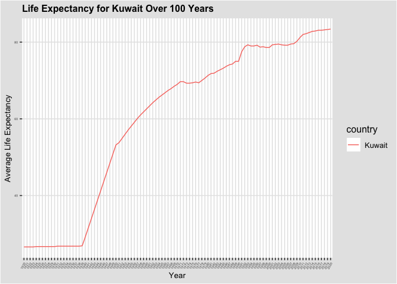

```r
life_expectancy_long %>%
  filter(between(year, 1920, 2020) & country=="Kuwait") %>%
  ggplot(aes(x=year, y=life_expectancy, color=country, group=country))+
  geom_line()+
  theme_igray()+
  theme(axis.text.x = element_text(angle = 60, hjust = 1))+
  labs(title = "Life Expectancy for Kuwait Over 100 Years",
       x = "Year",
       y = "Average Life Expectancy")+
  theme(plot.title = element_text(size = 12, face = "bold"),
        axis.text = element_text(size = 4),
        axis.title = element_text(size = 10))
```

Oil reserves were discovered in 1939.

## Population Growth

6. (3 points) Which 5 countries have had the highest population growth over the past 100 years (1920-2020)?

```r
population_total_100 <- population_longer %>%
  select(country, year, population) %>%
  filter(year==1920 | year==2020) %>%
  pivot_wider(names_from = year,
              names_prefix = "year_",
              values_from = population) %>%
  mutate(pop_growth_100= year_2020-year_1920) %>%
  arrange(desc(pop_growth_100))
population_total_100
```

```
## # A tibble: 195 × 4
##    country       year_1920  year_2020 pop_growth_100
##    <chr>             <dbl>      <dbl>          <dbl>
##  1 India         317000000 1380000000     1063000000
##  2 China         472000000 1440000000      968000000
##  3 Indonesia      47300000  274000000      226700000
##  4 United States 111000000  331000000      220000000
##  5 Pakistan       21700000  221000000      199300000
##  6 Brazil         27600000  213000000      185400000
##  7 Nigeria        23300000  206000000      182700000
##  8 Bangladesh     27300000  165000000      137700000
##  9 Mexico         14800000  129000000      114200000
## 10 Philippines     9400000  110000000      100600000
## # … with 185 more rows
```

The top 5 countries with highest population growth over the past 100 years are India, Indonesia, United States, Pakistan, and China

7. (4 points) Produce a plot that shows the 5 countries that have had the highest population growth over the past 100 years (1920-2020). Which countries appear to have had exponential growth?

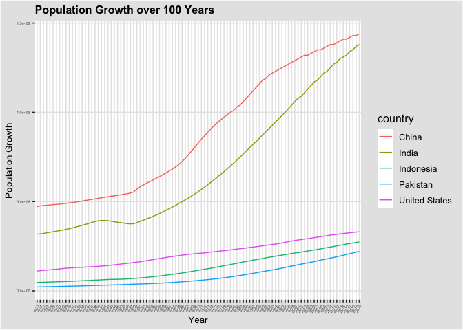

```r
population_longer %>%
  filter(between(year, 1920, 2020)) %>%
  filter(country=="India" | country=="China" | country=="Indonesia" | country=="United States" | country=="Pakistan") %>%
  ggplot(aes(x=year, y=population, color=country, group=country))+
  geom_line()+
  theme_igray()+
  theme(axis.text.x = element_text(angle = 60, hjust = 1))+
  labs(title = "Population Growth over 100 Years",
       x = "Year",
       y = "Population Growth")+
  theme(plot.title = element_text(size = 12, face = "bold"),
        axis.text = element_text(size = 4),
        axis.title = element_text(size = 10))
```

China and India apear to have exponential growth.

## Income

The units used for income are gross domestic product per person adjusted for differences in purchasing power in international dollars.

8. (4 points) As in the previous questions, which countries have experienced the biggest growth in per person GDP. Show this as a table and then plot the changes for the top 5 countries. With a bit of research, you should be able to explain the dramatic downturns of the wealthiest economies that occurred during the 1980’s. notes: compare change in gdp. between some of these countries. the change interpretation is the gdp at start and end and subtraction. this does not count for good and bad years.

```r
income_100 <- income_longer %>%
  select(country, year, income) %>%
  filter(year==1920 | year==2020) %>%
  pivot_wider(names_from = year,
              names_prefix = "year_",
              values_from = income) %>%
  mutate(income_100= year_2020-year_1920) %>%
  arrange(desc(income_100))
income_100
```

```
## # A tibble: 193 × 4
##    country              year_1920 year_2020 income_100
##    <chr>                    <dbl>     <dbl>      <dbl>
##  1 Qatar                     2300    116000     113700
##  2 Luxembourg                5730     95100      89370
##  3 Singapore                 2440     90500      88060
##  4 Brunei                    2130     75100      72970
##  5 Ireland                   5170     74100      68930
##  6 United Arab Emirates      2090     65300      63210
##  7 Kuwait                    2350     64300      61950
##  8 Norway                    8960     67500      58540
##  9 Monaco                    6630     62000      55370
## 10 San Marino                3280     57900      54620
## # … with 183 more rows
```

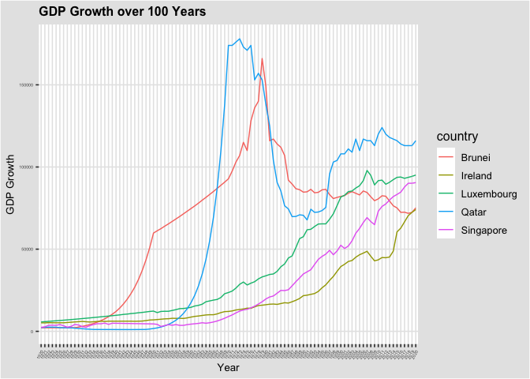

```r
income_longer %>%
  filter(between(year, 1920, 2020)) %>%
  filter(country=="Qatar" | country=="Luxembourg" | country=="Singapore" | country=="Brunei" | country=="Ireland") %>%
  ggplot(aes(x=year, y=income, color=country, group=country))+
  geom_line()+
  theme_igray()+
  theme(axis.text.x = element_text(angle = 60, hjust = 1))+
  labs(title = "GDP Growth over 100 Years",
       x = "Year",
       y = "GDP Growth")+
  theme(plot.title = element_text(size = 12, face = "bold"),
        axis.text = element_text(size = 4),
        axis.title = element_text(size = 10))
```

Countries with the greatest increase in GDP are Qatar, Luxembourg, Singapore, Ireland, and Brunei.

9. (3 points) Create three new objects that restrict each data set (life expectancy, population, income) to the years 1920-2020. Hint: I suggest doing this with the long form of your data. Once this is done, merge all three data sets using the code I provide below. You may need to adjust the code depending on how you have named your objects. I called mine `life_expectancy_100`, `population_100`, and `income_100`. For some of you, learning these `joins` will be important for your project.

```r
life_expectancy_100 <- life_expectancy_long %>%
  filter(between(year, 1920, 2020))
life_expectancy_100
```

```
## # A tibble: 18,887 × 3
##    country     year  life_expectancy
##    <chr>       <chr>           <dbl>
##  1 Afghanistan 1920             30.6
##  2 Afghanistan 1921             30.7
##  3 Afghanistan 1922             30.8
##  4 Afghanistan 1923             30.8
##  5 Afghanistan 1924             30.9
##  6 Afghanistan 1925             31
##  7 Afghanistan 1926             31
##  8 Afghanistan 1927             31.1
##  9 Afghanistan 1928             31.1
## 10 Afghanistan 1929             31.2
## # … with 18,877 more rows
```

```r
population_100 <- population_longer %>%
  filter(between(year, 1920, 2020))
population_100
```

```
## # A tibble: 19,695 × 3
##    country     year  population
##    <chr>       <chr>      <dbl>
##  1 Afghanistan 1920    10600000
##  2 Afghanistan 1921    10500000
##  3 Afghanistan 1922    10300000
##  4 Afghanistan 1923     9710000
##  5 Afghanistan 1924     9200000
##  6 Afghanistan 1925     8720000
##  7 Afghanistan 1926     8260000
##  8 Afghanistan 1927     7830000
##  9 Afghanistan 1928     7420000
## 10 Afghanistan 1929     7100000
## # … with 19,685 more rows
```

```r
income_100 <- income_longer %>%
  filter(between(year, 1920, 2020))
income_100
```

```
## # A tibble: 19,493 × 3
##    country     year  income
##    <chr>       <chr>  <dbl>
##  1 Afghanistan 1920    1490
##  2 Afghanistan 1921    1520
##  3 Afghanistan 1922    1550
##  4 Afghanistan 1923    1570
##  5 Afghanistan 1924    1600
##  6 Afghanistan 1925    1630
##  7 Afghanistan 1926    1650
##  8 Afghanistan 1927    1680
##  9 Afghanistan 1928    1710
## 10 Afghanistan 1929    1740
## # … with 19,483 more rows
```

```r
gapminder_join <- inner_join(life_expectancy_100, population_100, by= c("country", "year"))
gapminder_join <- inner_join(gapminder_join, income_100, by= c("country", "year"))
gapminder_join
```

```
## # A tibble: 18,887 × 5
##    country     year  life_expectancy population income
##    <chr>       <chr>           <dbl>      <dbl>  <dbl>
##  1 Afghanistan 1920             30.6   10600000   1490
##  2 Afghanistan 1921             30.7   10500000   1520
##  3 Afghanistan 1922             30.8   10300000   1550
##  4 Afghanistan 1923             30.8    9710000   1570
##  5 Afghanistan 1924             30.9    9200000   1600
##  6 Afghanistan 1925             31      8720000   1630
##  7 Afghanistan 1926             31      8260000   1650
##  8 Afghanistan 1927             31.1    7830000   1680
##  9 Afghanistan 1928             31.1    7420000   1710
## 10 Afghanistan 1929             31.2    7100000   1740
## # … with 18,877 more rows
```

10. (4 points) Use the joined data to perform an analysis of your choice. The analysis should include a comparison between two or more of the variables `life_expectancy`, `population`, or `income.`

For the 5 countries with the greatest GDP growth, how has their population growth changed over the 100 years?

Countries with the greatest increase in GDP are Qatar, Luxembourg, Singapore, Ireland, and Brunei.

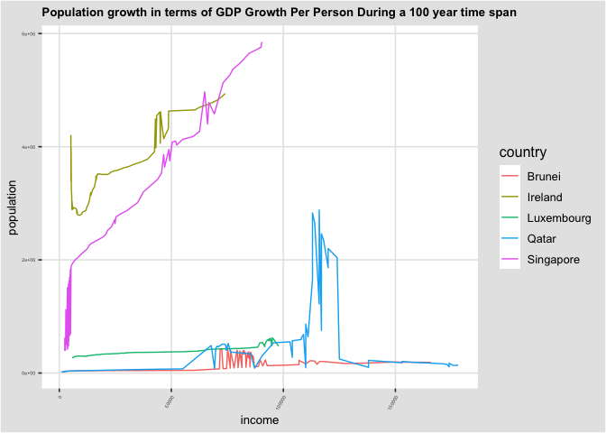

```r
income_pop_growth <- gapminder_join %>%
  select(country, income, population) %>%
  filter(country=="Qatar" | country=="Luxembourg" | country=="Singapore" | country=="Brunei" | country=="Ireland") %>%
  ggplot(aes(x=income, y=population, color=country, group=country))+
  geom_line()+
  theme_igray()+
  theme(axis.text.x = element_text(angle = 60, hjust = 1))+
  labs(title = "Population growth in terms of GDP Growth Per Person During a 100 year time span",
       x = "income",
       y = "population")+
  theme(plot.title = element_text(size = 10, face = "bold"),
        axis.text = element_text(size = 4),
        axis.title = element_text(size = 10))
income_pop_growth
```